# Quantative Trading Framework: USD/CAD Exchange Rate & Crude Price

#### 2023-12-06

## Strategy

- Momentum-based trading strategy intended to capitalize on the correlation that exists between crude prices and the CAD/USD exchange rate over certain periods
  - Utilizes a weighted 2 and 6 day Rate of Change of USO to predict USD/CAD exchange-rate directional in the near term
  - Market Entry/Exit strategy utilizing a 30 day rolling regression on USO and USD/CAD log returns

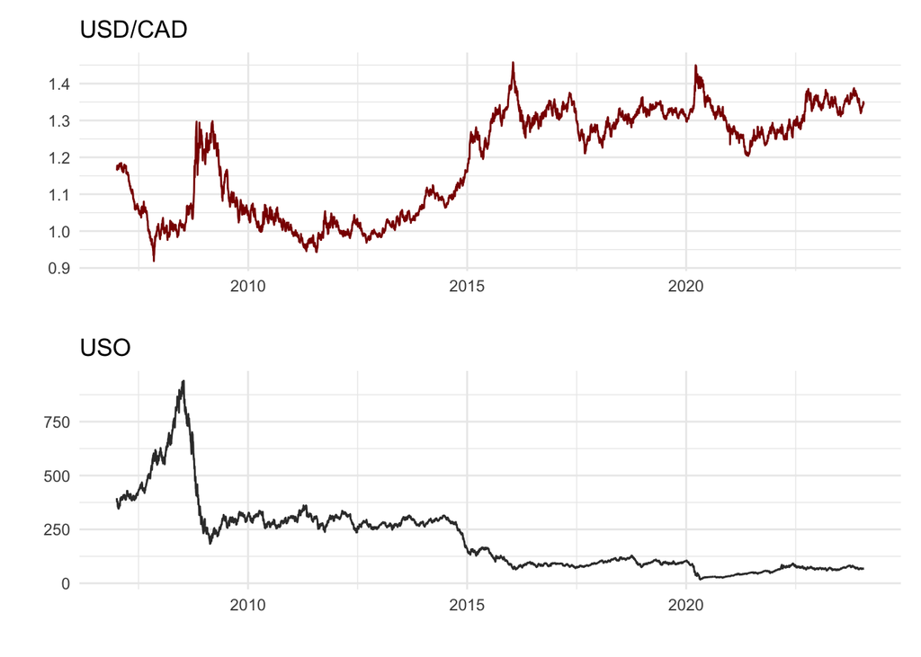

### Rationale

The foundations of the trade rely on principles of currency supply and demand, and their relationship between imports and exports between different economies

- Oil and gas extraction exports represent a significant percentage of Canada’s total exports (19.2% in 2022), with a majority of product going to the US
- Canadian energy products are generally exported to the US in exchange for USD, while Canadian producers incur significant costs in CAD
- When Oil Prices are high, the USD supply increases relative to CAD within Canada, increasing the CADs relative value
- Further, strong energy prices are often accompanied by net economic growth within Canada as producers are able to increase workforce and investment
- Following the above market fundamentals:
  - Positive momentum in crude prices should be reflected in a relative increase in CAD, vice versa
  - Due to the nature the currency inflow/outflow resulting from Oil Sales and Production (transport times, fixed-price production contracts, futures market etc.), one could expect that the currency-price effect of crude price change may not be fully realized in a single trading day
    - The trading strategy within this doc seeks to explore the possibility of this price disconnect

[interactive chart not shown]

### Research

- At its foundation, this strategy relies on a positive correlation between energy prices, and the Canadian dollars relative strength
  - As highlighted below, this relationship is not always present
- Given Canada’s relative economic diversification to some other ‘petrocurrency’ countries, factors such as policy interest rates reinvestment rate in the oil industry, and general macroeconomic trends can reduce this correlation
- Recent applicable factors include:
  - Reduction in investment confidence for Canadian oil with production cap risk, midstream issues, and high marginal costs per barrel
  - Relative high US policy interest rates
- Crude prices changes have less explanatory power in USD/CAD prices changes from 2016 onward
  - This reduction in Adj. R Squared will likely reduce trade model efficacy

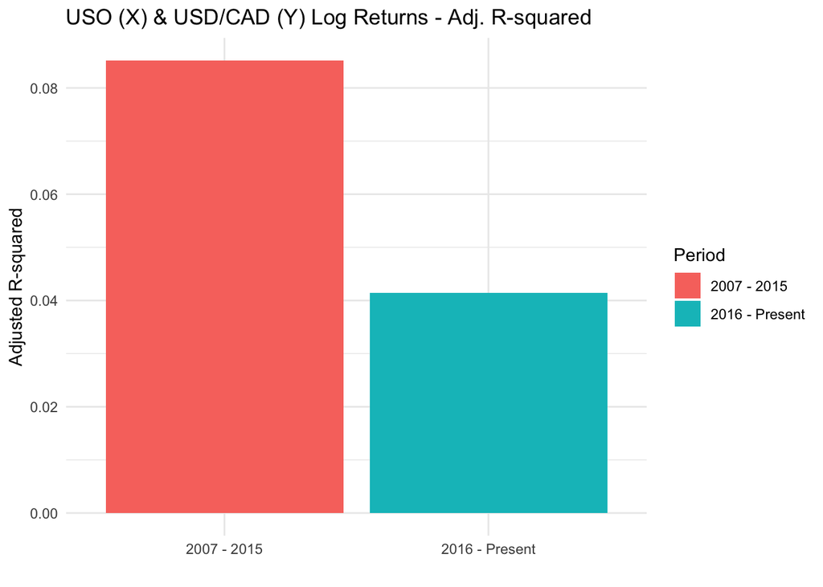

# Model Implementation

## Data

### Series Selected:

- United States Oil Fund (USO)
  - Exchanged traded security intended to capture the change in USO’s net asset value
    - The funds assets are composed of crude oil futures contracts and other oil-related contracts
  - Under performance relative to WTI spot price in recent time, in part due to negative roll yield associated with period of contango in the oil market
- CAD/USD Exchange Rate

## Signals & Trades

#### Signals Utilized

- 2 & 6 Day Rate of Change (ROC) of daily USO close price
  - The ROC used to generate a final signal is a weighted average of the two measures, with Alpha and Beta determining the 2 & 6 day weight, respectively
  - A weighted ROC of > 0 signals a short position in USD/CAD
  - A weighted ROC of < 0 signals a long position in USD/CAD
  - Combining ROCs with two different windows intents to reduce noise, given the volatility of daily returns
- 30 Day Rolling Regression of CAD/USD daily returns on USO daily returns
  - A statically significant (at Alpha = .1) and slope coefficient < 0 generates positive signal to enter/stay in the market
  - Any other combinations of signals signals a no trade/exit from the market
  - The use of these two measures intends capture the direction and significance of the impact USO returns have on CAD/USD returns on a daily basis a given point in time, using recent historical data
- Combined Signal
  - A final signal is generated that combines the long/short directional of the ROC signal, as well as the no trade/exit signal generate via the regression
    - If the regression signal does not indicated a no trade/exit, a long/short signal is generated in based on the sign of the ROC signal
    - If the regression signal indicates a no trade/exit, a signal of zero is generated
    - Corresponding USO price data is not available for all USD/CAD trading days; on days with missing price data, a 0 (no trade/exit) signal is generated

#### Trades

- Trades are generated using the combined signal from the previous day
  - 0 indicated that no market position should be held; no trade will occur, unless it is to close an existing position
  - 1 indicates short position USD/CAD
  - -1 indicates a long position USD/CAD

## Risk Appetite

- Minimize max drawdown length
  - Given the varying correlation between USO and CAD/USD returns, having a strategy that has shorted anticipated drawdowns (per the training set) could provide signs earlier, should the strategy start failing
    - Filter for lower 10% percentile
- Upper 10% percentileof Omegas
  - Ensure reasonable risk-to-reward
- Select highest cumulative return of the subset

## Performance

Risk Appetite-Based Selection

| alpha | beta | roc1 | roc2 | CumReturn |
| --- | --- | --- | --- | --- |
| 0.3333333 | 0.6666667 | 2 | 6 | 0.4862476 |
| 0.2500000 | 0.7500000 | 2 | 6 | 0.4668141 |
| 0.2000000 | 0.8000000 | 2 | 6 | 0.4621479 |

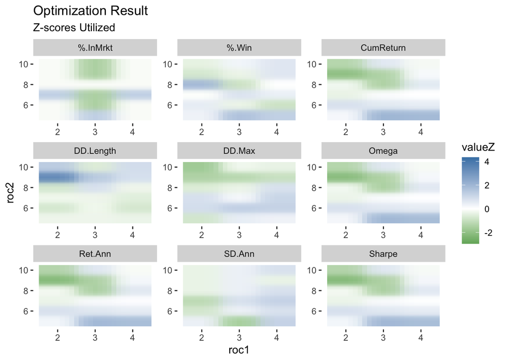

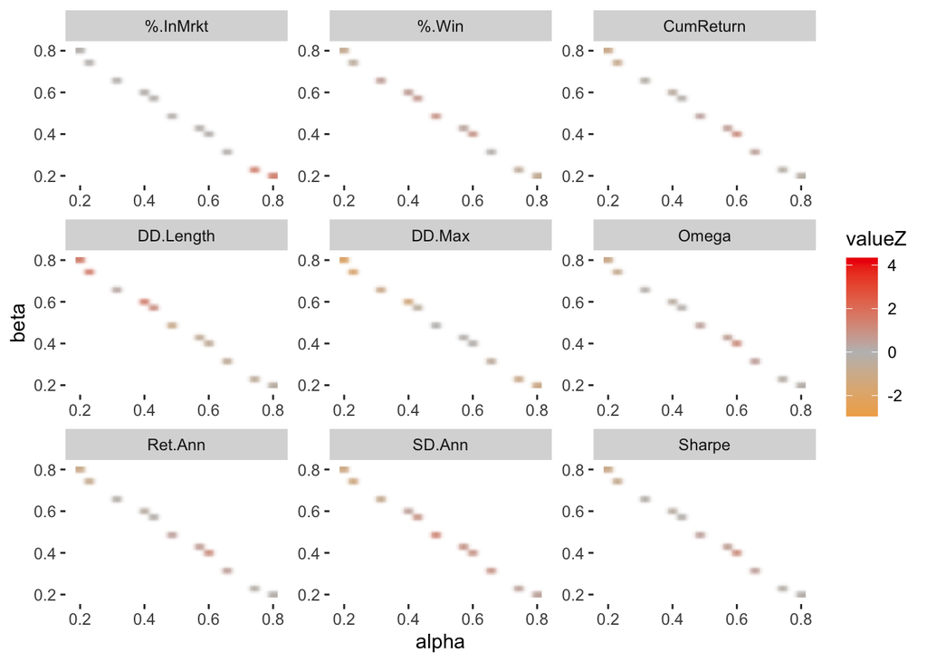

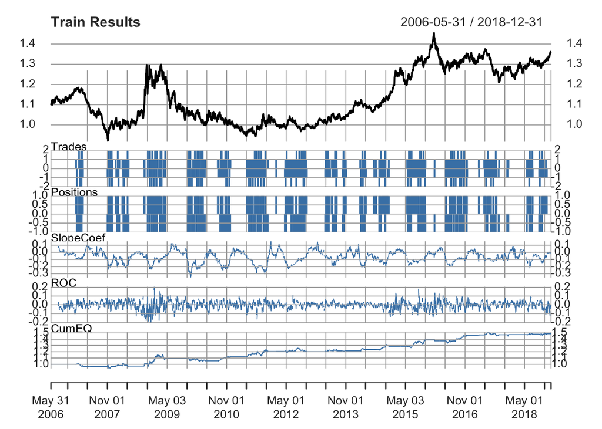

## Testing Period

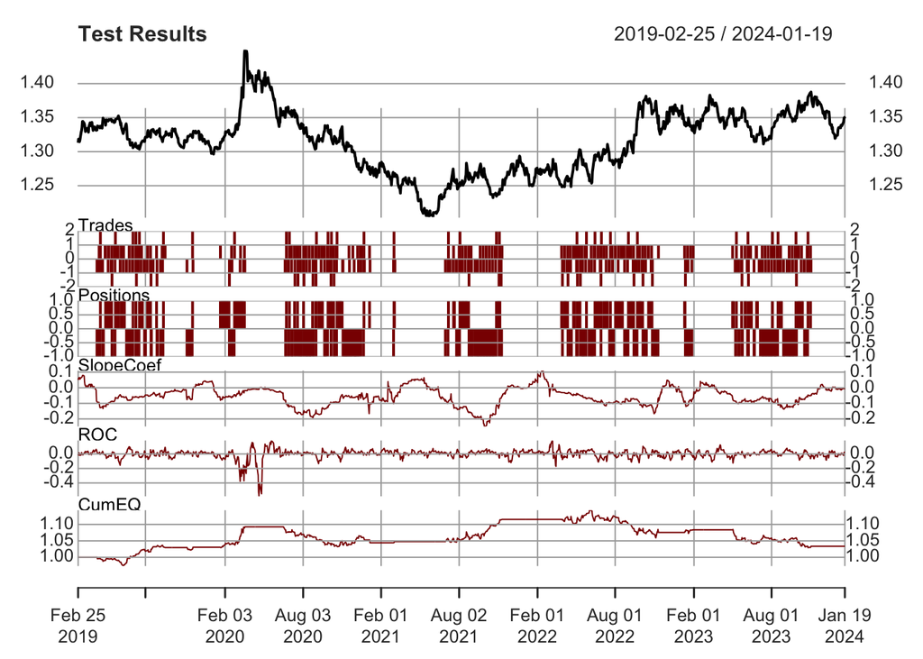

- Returns were strong though COVID volatility
  - Aligns patterns obeserved within the training set
  - Suggests that some variation of this trading model may provide utlity in higher volatility periods
- In-market percent was relatively unchanged from train period
  - Does not align with general sentiment, and statistical measures suggesting the CAD has somewaht disconnected from crude prices in recent time
    - Possibly indicative of a model failure

## Limitations & Learnings

#### Limitations

- As it stands, the model fails to consider transaction costs
- A historical-looking non-lagged rolling regression is an imperfect measure to capture whether or not pricing dynamics that the model seeks to capitalize on are occurring
  - Simply lagging USO returns a day does not solve the issue, given the 2 and 6 day ROC window
  - Further statistical testing/modelling is required to find more optimal metric to generate a no trade/exit signal
- Ideally position size would also be a function of the strength of the relationship between USO and USD/CAD prices at any given time

#### Learnings

- Data frequency and timeliness significantly limit the development of trading models that rely on non-financial market data sources
- Established and understood causal relationships are, unsurprisingly, challenging to profit from
- Attempting to leverage statistical measures in an applied setting where ones understanding is tested through a metric such as P&L is good at highlighting knowledge gaps